# Introduction

**Missing data**

**In statistics, missing data, or missing values, occur when no data value is stored for the variable in an observation. Missing data are a common occurrence and can have a significant effect on the conclusions that can be drawn from the data.**

**Missing data can occur because of nonresponse: no information is provided for one or more items or for a whole unit ("subject"). Some items are more likely to generate a nonresponse than others: for example items about private subjects such as income. Attrition is a type of missingness that can occur in longitudinal studies—for instance studying development where a measurement is repeated after a certain period of time. Missingness occurs when participants drop out before the test ends and one or more measurements are missing.**

**Data often are missing in research in economics, sociology, and political science because governments or private entities choose not to, or fail to, report critical statistics, or because the information is not available. Sometimes missing values are caused by the researcher—for example, when data collection is done improperly or mistakes are made in data entry**

Missing Values in Data The concept of missing values is important to understand in order to successfully manage data. If the missing values are not handled properly by the researcher, then he/she may end up drawing an inaccurate inference about the data. Due to improper handling, the result obtained by the researcher will differ from ones where the missing values are present.

Item non-response occurs when the respondent does not respond to certain questions due to stress, fatigue or lack of knowledge. The respondent may not respond because some questions are sensitive. These lack of answers would be considered missing values.

Handling Missing Values

The researcher may leave the data or do data imputation to replace the them. Suppose the number of cases of missing values is extremely small; then, an expert researcher may drop or omit those values from the analysis. In statistical language, if the number of the cases is less than 5% of the sample, then the researcher can drop them.

In the case of multivariate analysis, if there is a larger number of missing values, then it can be better to drop those cases (rather than do imputation) and replace them. On the other hand, in univariate analysis, imputation can decrease the amount of bias in the data, if the values are missing at random.

There are two forms of randomly missing values:

MCAR: Missing completely at random MAR: Missing at random The first form is missing completely at random (MCAR). This form exists when the missing values are randomly distributed across all observations. This form can be confirmed by partitioning the data into two parts: one set containing the missing values, and the other containing the non missing values. After partitioning the data, the most popular test, called the t-test of mean difference, is carried out in order to check whether there exists any difference in the sample between the two data-sets.

The researcher should keep in mind that if the data are MCAR, then he may choose a pair-wise or a list-wise deletion of missing value cases. If, however, the data are not MCAR, then imputation to replace them is conducted.

The second form is missing at random (MAR). In MAR, the missing values are not randomly distributed across observations but are distributed within one or more sub-samples. This form is more common than the previous one.

The non-ignorable missing value is the most problematic form which involves those types of missing values that are not randomly distributed across the observations. In this case, the probability cannot be predicted from the variables in the model. This can be ignored by performing data imputation to replace them.

```python
import pandas
import numpy
import matplotlib.pyplot as plt
from scipy import stats
%matplotlib inline
```

```python
from IPython.core.interactiveshell import InteractiveShell
InteractiveShell.ast_node_interactivity = "all"

pandas.set_option('display.max_columns', 52)
# pandas.set_option('display.max_rows', 52)
```

```python
# https://seaborn.pydata.org/tutorial/color_palettes.html
# style.available
import seaborn as sns
import matplotlib.style as style
style.use('_classic_test')
sns.set_palette('Blues_d')
```

```python
data =  pandas.read_csv('7210_1.csv', low_memory=False, memory_map=True)
```

# Data exploration

```python
data.sample(5)
```

|  | id | asins | brand | categories | colors | count | dateAdded | dateUpdated | descriptions | dimension | ean | features | flavors | imageURLs | isbn | keys | manufacturer | manufacturerNumber | merchants | name | prices.amountMin | prices.amountMax | prices.availability | prices.color | prices.condition | prices.count | prices.currency | prices.dateAdded | prices.dateSeen | … |
| --- | --- | --- | --- | --- | --- | --- | --- | --- | --- | --- | --- | --- | --- | --- | --- | --- | --- | --- | --- | --- | --- | --- | --- | --- | --- | --- | --- | --- | --- | --- |
| 2738 | AVpf_ZhPLJeJML43HF_U | NaN | Novica | Access.,Clothing,Shoes,Women's Clothing,Novica... | Grey,Multi | NaN | 2016-03-04T20:37:23Z | 2017-03-06T14:47:49Z | [{"dateSeen":["2017-03-26T10:04:25.874Z","2017... | NaN | NaN | [{"key":"Type","value":["Casual"]},{"key":"Wor... | NaN | http://ak1.ostkcdn.com/images/products/6663930... | NaN | novica/181893,cottongreyfloraltunicblouseindia... | NaN | 181893 | NaN | Cotton 'Grey Floral' Tunic Blouse (India) by N... | 59.99 | 59.99 | NaN | NaN | NaN | NaN | USD | 2017-03-28T11:55:43Z | 2017-03-26T10:04:25.874Z | … |
| 24636 | AVpjVU9PLJeJML43uB1l | NaN | Journee Collection | Flats,Shoes,Women's Shoes,Journee Collection | Black,Blue,Grey,Pink,Red,Silver | NaN | 2016-03-27T18:54:54Z | 2017-03-06T15:44:31Z | [{"dateSeen":["2017-03-25T09:32:10.672Z","2017... | NaN | NaN | [{"key":"Shoe Width","value":["Medium"]},{"key... | NaN | http://ak1.ostkcdn.com/images/products/1111012... | NaN | journeecollection/vika,journeecollectionwomens... | NaN | VIKA | NaN | Journee Collection Women's 'Vika' Round Toe Bo... | 31.87 | 31.87 | NaN | Black 7.5 | NaN | NaN | USD | 2017-03-28T11:40:36Z | 2017-03-25T09:32:10.672Z | … |
| 5779 | AVpfDW8qilAPnD_xT4xW | NaN | Nature Breeze | Boots On Sale,Shoes,Women's Shoes,Boots,Clothi... | Black,Brown,Grey,Red,Tan,Taupe,Wine | NaN | 2017-01-22T20:15:28Z | 2017-03-28T11:40:35Z | [{"dateSeen":["2017-03-25T09:31:53.949Z","2017... | NaN | 1.912460e+11 | [{"key":"Boot Height","value":["Knee-High Boot... | NaN | https://i5.walmartimages.com/asr/f2c2e1c9-b367... | NaN | naturebreeze/fe61,naturebreezefe61womensnapcuf... | NaN | FE61 | [{"dateSeen":["2017-01-27T01:31:30Z"],"name":"... | NATURE BREEZE FE61 Women Snap Cuff Over The Kn... | 44.99 | 44.99 | NaN | WINE 9 | NaN | NaN | USD | 2017-02-03T22:29:39Z | 2017-01-26T00:00:00Z | … |
| 5908 | AVpfEAgF1cnluZ0-dE6Z | NaN | Novica | Access.,Clothing,Shoes,Women's Clothing,Novica... | Beige | NaN | 2016-03-04T20:07:01Z | 2017-03-06T14:47:50Z | [{"dateSeen":["2017-03-26T04:55:50.301Z","2017... | NaN | NaN | [{"key":"Type","value":["Casual"]},{"key":"Wor... | NaN | http://ak1.ostkcdn.com/images/products/7301074... | NaN | novica/197460,womenscottondesertdancertunicind... | NaN | 197460 | NaN | Women's Cotton 'Desert Dancer' Tunic (India) b... | 47.49 | 47.49 | NaN | NaN | NaN | NaN | USD | 2016-03-04T20:07:01Z | 2016-05-25T00:00:00Z | … |
| 14934 | AVpfZY6G1cnluZ0-kDAZ | NaN | MUK LUKS | Shoes,Clothing,Women's Shoes,All Women's Shoes | Tan | NaN | 2016-04-23T16:01:55Z | 2016-05-04T22:18:31Z | NaN | NaN | 3.397715e+10 | [{"key":"Gender","value":["Women"]},{"key":"Sh... | NaN | http://i5.walmartimages.com/dfw/dce07b8c-4c7b/... | NaN | 033977154858,0033977154858,reliableofmilwaukee... | Reliable of Milwaukee | 0016457230-6 | [{"dateSeen":["2016-04-23T16:01:55Z"],"name":"... | Muk Luks Women's Susan Sandals | 39.00 | 39.00 | NaN | NaN | new | NaN | USD | 2016-04-23T16:01:55Z | 2016-05-03T00:00:00Z | … |

```python
data.info()
```

```
<class 'pandas.core.frame.DataFrame'>
RangeIndex: 33801 entries, 0 to 33800
Data columns (total 52 columns):
id                     33801 non-null object
asins                  2422 non-null object
brand                  32817 non-null object
categories             33801 non-null object
colors                 19844 non-null object
count                  0 non-null float64
dateAdded              33801 non-null object
dateUpdated            33801 non-null object
descriptions           28425 non-null object
dimension              1177 non-null object
ean                    9778 non-null float64
features               27181 non-null object
flavors                0 non-null float64
imageURLs              22309 non-null object
isbn                   0 non-null float64
keys                   33801 non-null object
manufacturer           9279 non-null object
manufacturerNumber     31434 non-null object
merchants              15382 non-null object
name                   33801 non-null object
prices.amountMin       33801 non-null float64
prices.amountMax       33801 non-null float64
prices.availability    307 non-null object
prices.color           17421 non-null object
prices.condition       12015 non-null object
prices.count           0 non-null float64
prices.currency        33801 non-null object
prices.dateAdded       33801 non-null object
prices.dateSeen        33801 non-null object
prices.flavor          0 non-null float64
prices.isSale          33801 non-null bool
prices.merchant        29926 non-null object
prices.offer           6798 non-null object
prices.returnPolicy    1374 non-null object
prices.shipping        3948 non-null object
prices.size            15391 non-null object
prices.source          0 non-null float64
prices.sourceURLs      33801 non-null object
prices.warranty        0 non-null float64
quantities             18490 non-null object
reviews                4188 non-null object
sizes                  8602 non-null object
skus                   22135 non-null object
sourceURLs             33801 non-null object
upc                    10724 non-null float64
vin                    0 non-null float64
websiteIDs             0 non-null float64
weight                 1263 non-null object
Unnamed: 48            0 non-null float64
Unnamed: 49            0 non-null float64
Unnamed: 50            0 non-null float64
Unnamed: 51            1 non-null object
dtypes: bool(1), float64(16), object(35)
memory usage: 13.2+ MB
```

It is important to check in the initial stages itself for the presence of **duplicates** in the data

```python
f'dupliates: {data.duplicated().sum()}'
data.drop_duplicates(inplace=True)
data.shape
```

```
'dupliates: 3'
```

```
(33798, 52)
```

so we could able to recognize rows which are completely duplicates and retain three of the first original rows and drop rest of the duplicates

# Data Visualization

## The infamous NaN or missing values in the data

```python
data.isnull().sum()
data.shape
```

```
id                         0
asins                  31379
brand                    984
categories                 0
colors                 13956
count                  33798
dateAdded                  0
dateUpdated                0
descriptions            5373
dimension              32621
ean                    24020
features                6617
flavors                33798
imageURLs              11492
isbn                   33798
keys                       0
manufacturer           24519
manufacturerNumber      2367
merchants              18416
name                       0
prices.amountMin           0
prices.amountMax           0
prices.availability    33491
prices.color           16377
prices.condition       21783
prices.count           33798
prices.currency            0
prices.dateAdded           0
prices.dateSeen            0
prices.flavor          33798
prices.isSale              0
prices.merchant         3875
prices.offer           27000
prices.returnPolicy    32424
prices.shipping        29851
prices.size            18407
prices.source          33798
prices.sourceURLs          0
prices.warranty        33798
quantities             15308
reviews                29612
sizes                  25196
skus                   11663
sourceURLs                 0
upc                    23074
vin                    33798
websiteIDs             33798
weight                 32535
Unnamed: 48            33798
Unnamed: 49            33798
Unnamed: 50            33798
Unnamed: 51            33797
dtype: int64
```

```
(33798, 52)
```

## visualization of NaN or Visualization of missing values

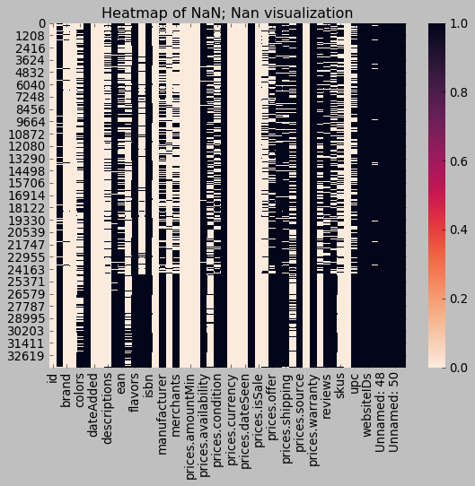

```python
def naheatmap(data):
    sns.heatmap(data.isnull(), annot=False,cmap=sns.cm.rocket_r);
    plt.title('Heatmap of NaN; Nan visualization');
naheatmap(data)
```

```python
def fetch_null(data):
    null = data.isna().sum()/len(data)*100
    null = null[null>0]
    null.sort_values(inplace=True, ascending= False)
    null = pandas.DataFrame({'percent' : null})
    return null
fetch_null(data)
```

|  | percent |
| --- | --- |
| prices.flavor | 100.000000 |
| prices.warranty | 100.000000 |
| Unnamed: 49 | 100.000000 |
| Unnamed: 48 | 100.000000 |
| count | 100.000000 |
| websiteIDs | 100.000000 |
| vin | 100.000000 |
| flavors | 100.000000 |
| isbn | 100.000000 |
| prices.count | 100.000000 |
| Unnamed: 50 | 100.000000 |
| prices.source | 100.000000 |
| Unnamed: 51 | 99.997041 |
| prices.availability | 99.091662 |
| dimension | 96.517545 |
| weight | 96.263092 |
| prices.returnPolicy | 95.934671 |
| asins | 92.842772 |
| prices.shipping | 88.321794 |
| reviews | 87.614652 |
| prices.offer | 79.886384 |
| sizes | 74.548790 |
| manufacturer | 72.545713 |
| ean | 71.069294 |
| upc | 68.270312 |
| prices.condition | 64.450559 |
| merchants | 54.488431 |
| prices.size | 54.461802 |
| prices.color | 48.455530 |
| quantities | 45.292621 |
| colors | 41.292384 |
| skus | 34.507959 |
| imageURLs | 34.002012 |
| features | 19.578082 |
| descriptions | 15.897390 |
| prices.merchant | 11.465175 |
| manufacturerNumber | 7.003373 |
| brand | 2.911415 |

## Bar plot NaN

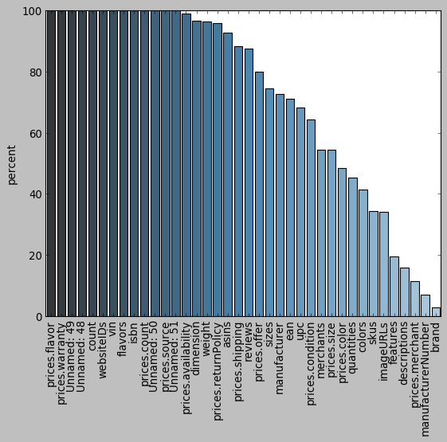

```python
def plot_null(null):
    ax = sns.barplot(null.index,null.percent, palette="Blues_d");
    plt.xticks(rotation = 90);
plot_null(fetch_null(data))
```

Its time to drop columns which are completely null or atleast 99% null i.e ~33798*99% ie ~ 33460 removing columns with NaN more than 99%,this will remove *prices.availability* it holds 99.091662% NaNs ,an important feature for sure! but we can afford to loose the data

```python
# Its time to drop columns which are completely null or atleast 99% null
data.dropna(axis=1,how='all',thresh=338 ,inplace=True); # thresh ~33460 i.e 338
```

## save intermediate file

```python
data_version1 = data.copy()
```

## lets see how our NaN looks after dropping some NaN columns

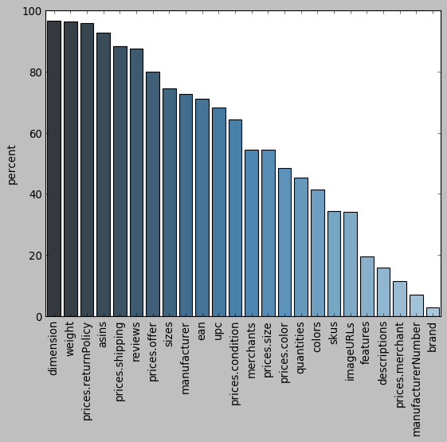

```python
plot_null(fetch_null(data))
```

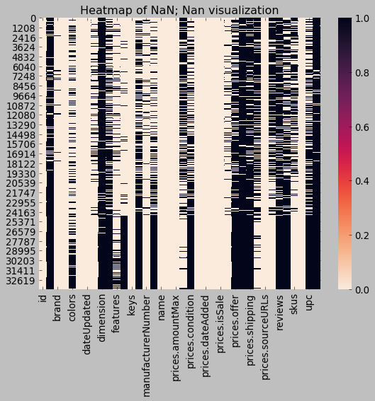

```python
naheatmap(data)
```

**lets dig deep and check each and every column to see whether it is important or we can afford to loose it**

# cleaning

our agenda is to find

1.What is the average price of each distinct brand listed? 2.Which brands have the highest prices? 3.Which ones have the widest distribution of prices? 4.Is there a typical price distribution (e.g., normal) across brands or within specific brands?

To answer these above questions we don't need any of the below but for future analysis of data lets say price valuation of newly arrived shoe design , for this we may or may not need some of these feature .

It is always advised to have the data but not need it than need the data but not have it !

dimension 96.517545% NaN : price of shoe is pretty much same for average sizes but may vary for rare sizes like size 12 ; drop | weight 96.263092 : definitely an important feature , nobody wants to wear a heavy shoes ; no drop

prices.returnPolicy 95.934671 : unfortunate that 95% data is not available, brands with more open return policy definitely outperform brands with no return policy ; no drop | asins 92.842772 : drop | prices.shipping 88.321794 : directly proportional to pricing ; no drop | reviews 87.614652 : not needed for pricing ; drop : although reviews are good information of customer satisfaction ; the information available is very low ; may create bias | prices.offer 79.886384 : most crucial data , cant drop it | sizes 74.548790 ; again drop, although this data can be used to compare abnormal prices | manufacturer 72.545713 ; crucial for seller but not for buyer, buyer only cares about brand | ean 71.069294 : drop , upc 68.270312 : drop | prices.condition 64.450559 : very important | merchants 54.488431 : important | prices.size 54.461802 : important | prices.color 48.455530 : important | quantities 45.292621 : drop | colors 41.292384 : very important | skus 34.507959 : drop | imageURLs 34.002012 : no drop| features 19.578082 : very important in fact it is hiding some very useful information | descriptions 15.897390 : important | prices.merchant 11.465175 : important |manufacturerNumber 7.003373 : drop

## drop columns which are not necessary for the analysis

```python
data.drop(['dimension', 'asins', 'reviews', 'sizes', 'ean', 'upc', 'quantities', 'skus', 'imageURLs','manufacturerNumber'], axis=1, inplace=True)
```

```python
data.shape # now we have 27 rows
data.sample(3)
```

```
(33798, 28)
```

|  | id | brand | categories | colors | dateAdded | dateUpdated | descriptions | features | keys | manufacturer | merchants | name | prices.amountMin | prices.amountMax | prices.color | prices.condition | prices.currency | prices.dateAdded | prices.dateSeen | prices.isSale | prices.merchant | prices.offer | prices.returnPolicy | prices.shipping | prices.size | prices.sourceURLs | sourceURLs | weight |
| --- | --- | --- | --- | --- | --- | --- | --- | --- | --- | --- | --- | --- | --- | --- | --- | --- | --- | --- | --- | --- | --- | --- | --- | --- | --- | --- | --- | --- |
| 2080 | AVpe93o11cnluZ0-a7bM | Beston | Boots On Sale,Shoes,Women's Shoes,Boots | Black,Blue,Brown,Grey,Red | 2017-02-03T22:25:54Z | 2017-03-28T11:40:39Z | [{"dateSeen":["2017-03-25T09:35:52.369Z","2017... | [{"key":"Boot Height","value":["Standard Boots... | beston/gf58,bestonwomensgf58drawstringinsidezi... | NaN | NaN | Beston Women's GF58 Drawstring Inside Zip Bloc... | 35.19 | 35.19 | BCK DENIM 10 | NaN | USD | 2017-03-28T11:40:39Z | 2017-03-25T09:35:52.369Z | False | Overstock.com | NaN | NaN | NaN | LA | https://www.overstock.com/Clothing-Shoes/Besto... | https://www.overstock.com/Clothing-Shoes/Besto... | NaN |
| 30443 | AVsUugKnv8e3D1O-mEoc | Blue | Flats,Shoes,Women's Shoes | Black,Silver | 2017-03-28T11:43:06Z | 2017-03-28T11:43:06Z | [{"dateSeen":["2017-03-25T12:23:20.273Z"],"sou... | [{"key":"Shoe Width","value":["Medium"]},{"key... | bluewomenspasserballerinaflats/16284267,blue/l... | NaN | NaN | Blue Women's 'Passer' Ballerina Flats | 22.39 | 22.39 | BCK/SILVER 9 | NaN | USD | 2017-03-28T11:43:06Z | 2017-03-25T12:23:20.273Z | False | Overstock.com | NaN | NaN | NaN | LA | https://www.overstock.com/Clothing-Shoes/Blue-... | https://www.overstock.com/Clothing-Shoes/Blue-... | NaN |
| 16348 | AVpgeqpw1cnluZ0-2BUx | FAMOUS NAME BRAND | Shoes,Women's Shoes,Clothing,All Women's Shoes | NaN | 2016-05-19T18:30:04Z | 2016-05-19T18:42:16Z | NaN | [{"key":"Heel Height","value":["Flat (0 to 1/2... | famousnamebrand/00970900 | NaN | [{"dateSeen":["2016-05-19T18:30:04Z"],"name":"... | Famous Name Brand Shore Leave Women Us 6 Tan S... | 50.00 | 50.00 | NaN | new | USD | 2016-05-19T18:30:04Z | 2016-05-18T00:00:00Z | False | ApparelSave - Walmart.com | NaN | NaN | NaN | NaN | http://www.walmart.com/ip/Famous-Name-Brand-Sh... | http://www.walmart.com/ip/Famous-Name-Brand-Sh... | NaN |

## let's see our NaN again

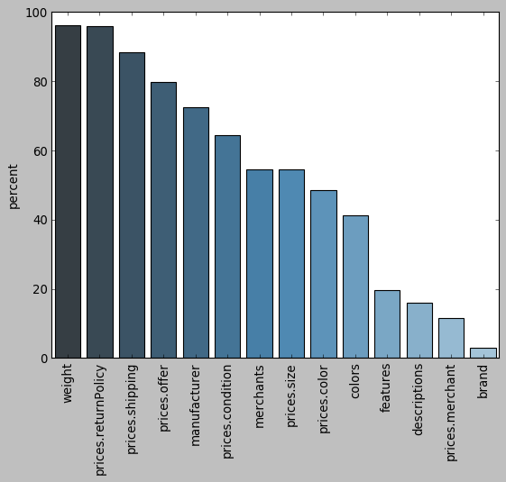

```python
plot_null(fetch_null(data))
```

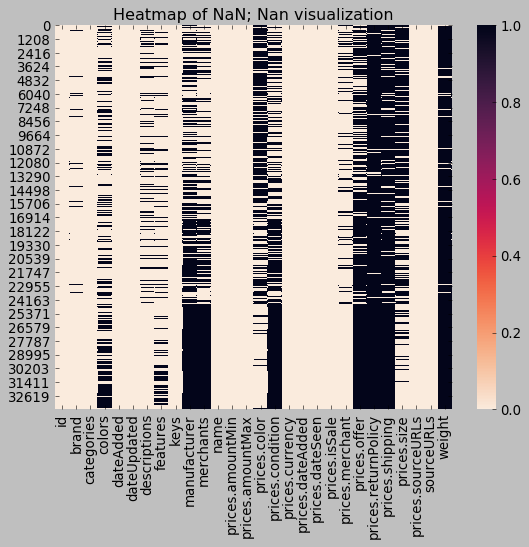

```python
naheatmap(data)
```

## we save our intermediate file

```python
data_version2 = data.copy() # # data_version2 = ddata_version1 minus  columns dimension asins reviews sizes ean upc quantities
# skus imageURLs manufacturerNumber
data_version2.to_csv('data_version2.csv') # it is a 68 MB file so takes some time to process depending on the system (3 sec max)
```

## Remove non ascii characters form the dataframe

```python
u = data.select_dtypes(object)
data[u.columns] = u.apply(lambda x: x.str.encode('ascii', 'ignore').str.decode('ascii'))
```

Removed those malicious non ascii entries which are not needed for women shoe pricing